# Global Ecology Digest from May 18, 2026 to June 01, 2026

##### 📄 Temporal shifts in kelp forest structure and distribution reflect ocean warming trends ✨ AI title

Shared by **Ecography** [@ecography.bsky.social](https://bsky.app/profile/ecography.bsky.social) · 2026-05-27 · 💚 8 likes on Bluesky

```
<div class='tag-row'><span class='tag tag-coastal'>coastal</span><span class='tag tag-climate'>climate</span><span class='tag tag-macroecology'>macroecology</span></div>
{% raw %}Temporal shifts in kelp forest structure and distribution largely reflect recent ocean warming trends vist.ly/55kj2 KelpForests OceanWarming SpeciesDistribution{% endraw %}
```

**link:** https://vist.ly/55kj2  
[View Original Post on Bluesky](https://bsky.app/profile/did:plc:gzozs2g2etnvprbwjby4ujhu/post/3mmt6rm5ovw2l)↑ Up

[output not shown]

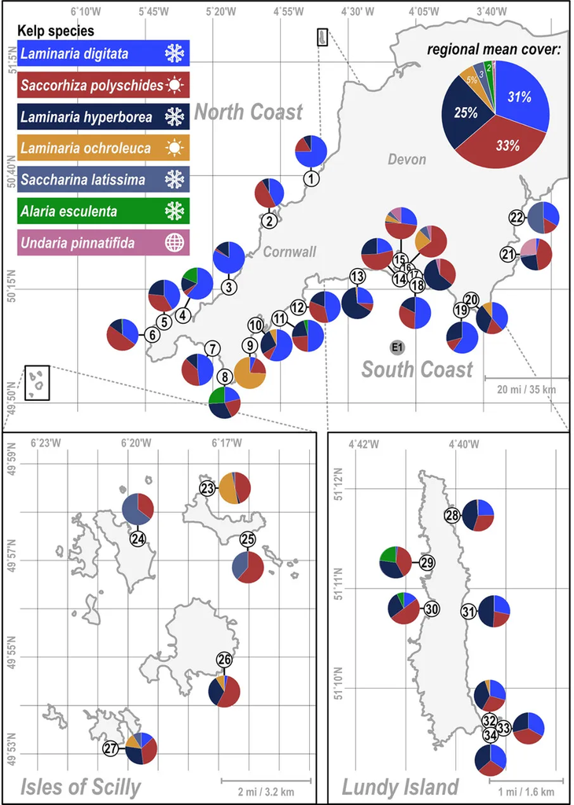

##### 📄 Response diversity stabilizes communities depending on disturbance regime and species interactions ✨ AI title

Shared by **Frank Burdon** [@fburdon.bsky.social](https://bsky.app/profile/fburdon.bsky.social) · 2026-05-27 · 💚 12 likes on Bluesky

```
<div class='tag-row'><span class='tag tag-traits'>traits</span></div>
{% raw %}The role of response diversity in promoting community stability depends on disturbance regimes and is shaped by species interactions. Stability following pulse disturbances was highest when multiple interacting species uniformly exhibited strong resistance or fast recovery{% endraw %}
```

**link:** https://onlinelibrary.wiley.com/doi/10.1111/ele.70299?utm_medium=article&utm_source=researchgate.net  
[View Original Post on Bluesky](https://bsky.app/profile/did:plc:hogz5yygw2s5lmt3fk2netxh/post/3mmt2spx6gk2x)↑ Up

[output not shown]

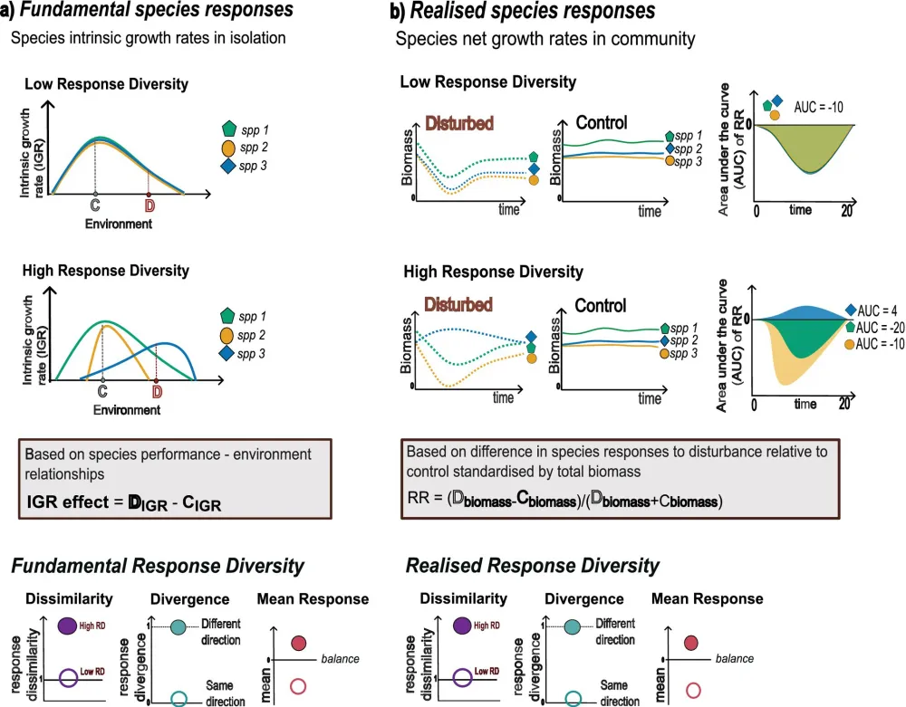

##### 📄 Global meta-analysis reveals urban-associated behavioural differences in wild populations ✨ AI title

Shared by **Journal of Animal Ecology** [@animalecology.bsky.social](https://bsky.app/profile/animalecology.bsky.social) · 2026-05-27 · 💚 7 likes on Bluesky

```
<div class='tag-row'><span class='tag tag-macroecology'>macroecology</span><span class='tag tag-traits'>traits</span></div>
{% raw %}This new Global meta-analysis reveals urban-associated behavioural differences among wild populations 🌍 🔎 🦚 👇️ Read more buff.ly/ZpXeLw3{% endraw %}
```

**link:** https://buff.ly/ZpXeLw3  
[View Original Post on Bluesky](https://bsky.app/profile/did:plc:cvm6m4ardajaxaw57d6uqms4/post/3mmt22sojdt2a)↑ Up

[output not shown]

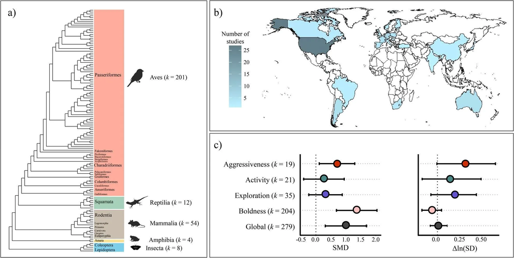

##### 📄 Selecting among counterfactual methods to evaluate conservation interventions ✨ AI title

Shared by **Pablo Garcia-Diaz** [@pablo-ecology.bsky.social](https://bsky.app/profile/pablo-ecology.bsky.social) · 2026-05-26 · 💚 7 likes on Bluesky

```
<div class='tag-row'><span class='tag tag-methods'>methods</span></div>
{% raw %}Selecting among counterfactual methods to evaluate conservation interventions 🌎🌐🧪 @conservationsp.bsky.social{% endraw %}
```

**link:** https://conbio.onlinelibrary.wiley.com/doi/full/10.1111/csp2.70066  
[View Original Post on Bluesky](https://bsky.app/profile/did:plc:jvl2oy4s2hpizxkbd7ngq7ty/post/3mmrkpqk7ns2e)↑ Up

[output not shown]

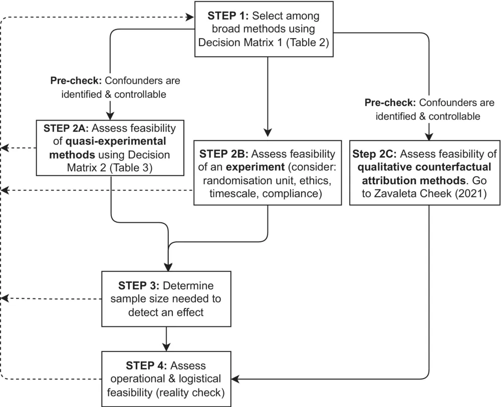

##### 📄 Precision ecology for targeted conservation action

Shared by **James Bullock** [@jmbecologist.bsky.social](https://bsky.app/profile/jmbecologist.bsky.social) · 2026-05-26 · 💚 30 likes on Bluesky

```
<div class='tag-row'><span class='tag tag-methods'>methods</span></div>
{% raw %}Evidence-based approaches to conservation have 2 problems 1) Generalised evidence doesn’t take account of context 2) Specific information isn’t transferable Precision Ecology addresses these problems And we’re now starting a grant to test PE & provide guidance!{% endraw %}
```

**link:** https://www.nature.com/articles/s41559-025-02733-4  
[View Original Post on Bluesky](https://bsky.app/profile/did:plc:n5f6mgg4yicla5z3e2blr3kz/post/3mmrjsgtxhk2w)↑ Up

[output not shown]

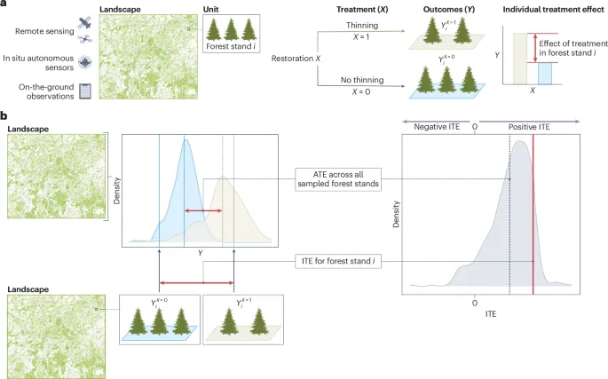

##### 📄 The value of qualitative approaches to impact evaluation in biodiversity conservation ✨ AI title

Shared by **Pablo Garcia-Diaz** [@pablo-ecology.bsky.social](https://bsky.app/profile/pablo-ecology.bsky.social) · 2026-05-26 · 💚 7 likes on Bluesky

```
<div class='tag-row'><span class='tag tag-policy'>policy</span><span class='tag tag-methods'>methods</span></div>
{% raw %}The value of qualitative approaches to impact evaluation in biodiversity conservation 🌎🌐🧪{% endraw %}
```

**link:** https://conbio.onlinelibrary.wiley.com/doi/10.1111/csp2.70102  
[View Original Post on Bluesky](https://bsky.app/profile/did:plc:jvl2oy4s2hpizxkbd7ngq7ty/post/3mmrija27fs2r)↑ Up

[output not shown]

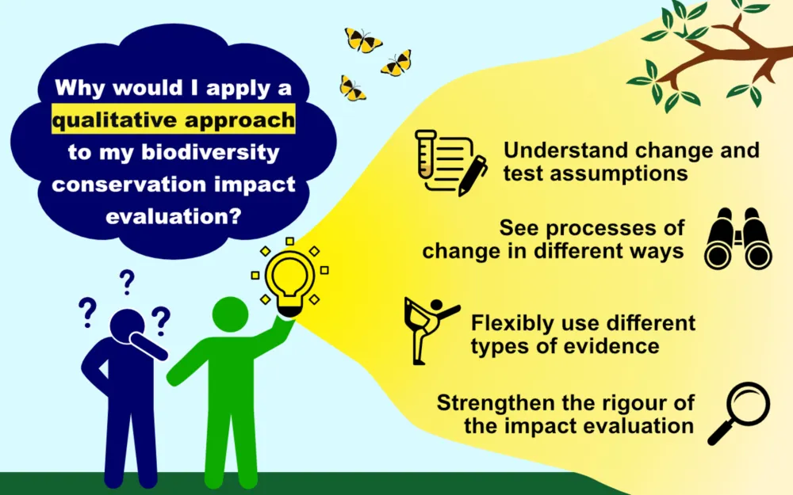

##### 📄 Accounting for human–nature linkages in area-based conservation monitoring through social–ecological indicator bundles ✨ AI title

Shared by **Pablo Garcia-Diaz** [@pablo-ecology.bsky.social](https://bsky.app/profile/pablo-ecology.bsky.social) · 2026-05-26 · 💚 3 likes on Bluesky

```
<div class='tag-row'><span class='tag tag-ecosystem-services'>ecosystem-services</span><span class='tag tag-policy'>policy</span><span class='tag tag-methods'>methods</span></div>
{% raw %}Accounting for human–nature linkages in area-based conservation monitoring through social–ecological indicator bundles 🌎🌐🧪{% endraw %}
```

**link:** https://conbio.onlinelibrary.wiley.com/doi/10.1111/cobi.70156  
[View Original Post on Bluesky](https://bsky.app/profile/did:plc:jvl2oy4s2hpizxkbd7ngq7ty/post/3mmre6qqpx225)↑ Up

[output not shown]

[figure not shown]

##### 📄 Rewilding: ten years of evolution and development ✨ AI title

Shared by **Pablo Garcia-Diaz** [@pablo-ecology.bsky.social](https://bsky.app/profile/pablo-ecology.bsky.social) · 2026-05-26 · 💚 18 likes on Bluesky

```
<div class='tag-row'><span class='tag tag-policy'>policy</span></div>
{% raw %}Rewilding: Ten Years of Evolution and Development 🌎🌐🧪{% endraw %}
```

**link:** https://www.annualreviews.org/content/journals/10.1146/annurev-environ-111523-102359  
[View Original Post on Bluesky](https://bsky.app/profile/did:plc:jvl2oy4s2hpizxkbd7ngq7ty/post/3mmr5c7fobc2j)↑ Up

[output not shown]

[figure not shown]

##### 📄 Amazon climate corridors in Peru critical for tropical biodiversity survival ✨ AI title

Shared by **ForestPlots** [@forestplots.bsky.social](https://bsky.app/profile/forestplots.bsky.social) · 2026-05-26 · 💚 15 likes on Bluesky

```
<div class='tag-row'><span class='tag tag-tropical-forest'>tropical-forest</span><span class='tag tag-climate'>climate</span><span class='tag tag-macroecology'>macroecology</span><span class='tag tag-policy'>policy</span></div>
{% raw %}Is Peru the most important nation on Earth for the future of tropical life? To escape increasing heat and drought, the Amazon needs big, protected ecosystem corridors. This new study shows where they need to be.{% endraw %}
```

**link:** https://www.sciencedirect.com/science/article/pii/S2351989426001836?via%3Dihub&fbclid=IwY2xjawSCZEtleHRuA2FlbQIxMABzcnRjBmFwcF9pZBAyMjIwMzkxNzg4MjAwODkyAAEeD5u1Y6dUUsfKs_gTrcbbF0nAl018RTL-3sDPb0EPW1SFu9MKmxLdTASTNXo_aem_sBQT1dD1hALbCPDXoa402A  
[View Original Post on Bluesky](https://bsky.app/profile/did:plc:neh6ptepenqtxvdxkeu5twct/post/3mmqvo7ioek2a)↑ Up

[output not shown]

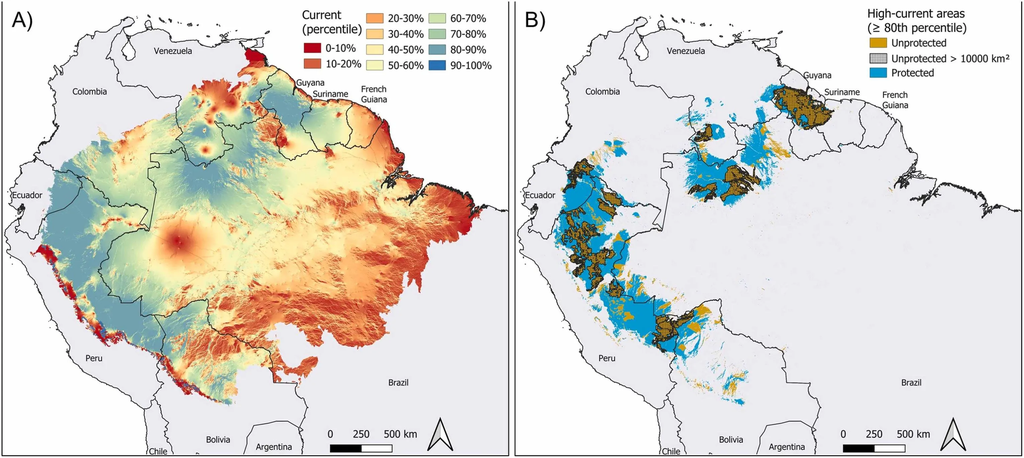

##### 📄 Webinar: Eco-evolutionary modelling seminar featuring Korinna Allhoff ✨ AI title

Shared by **Institut Natura e Teoria ※ Pireneus (INTP)** [@intp-science.bsky.social](https://bsky.app/profile/intp-science.bsky.social) · 2026-05-26 · 💚 6 likes on Bluesky

[output not shown]

**link:** https://eco-evolutionary-modelling.uni-hohenheim.de/en/english  
[View Original Post on Bluesky](https://bsky.app/profile/did:plc:ojhu5hugdadurowr4wsqrv47/post/3mmqqpb63zk2c)↑ Up

[output not shown]

[figure not shown]

##### 📄 Habitat fragmentation can either increase or decrease with habitat loss

Shared by **Federico Riva** [@rivaecology.bsky.social](https://bsky.app/profile/rivaecology.bsky.social) · 2026-05-25 · 💚 6 likes on Bluesky

```
<div class='tag-row'><span class='tag tag-macroecology'>macroecology</span></div>
{% raw %}Habitat fragmentation can either increase or decrease with habitat loss{% endraw %}
```

**link:** https://link.springer.com/article/10.1007/s10980-026-02345-8  
[View Original Post on Bluesky](https://bsky.app/profile/did:plc:4lh72xky3wwxw2v74k7upkr6/post/3mmpautibak26)↑ Up

[output not shown]

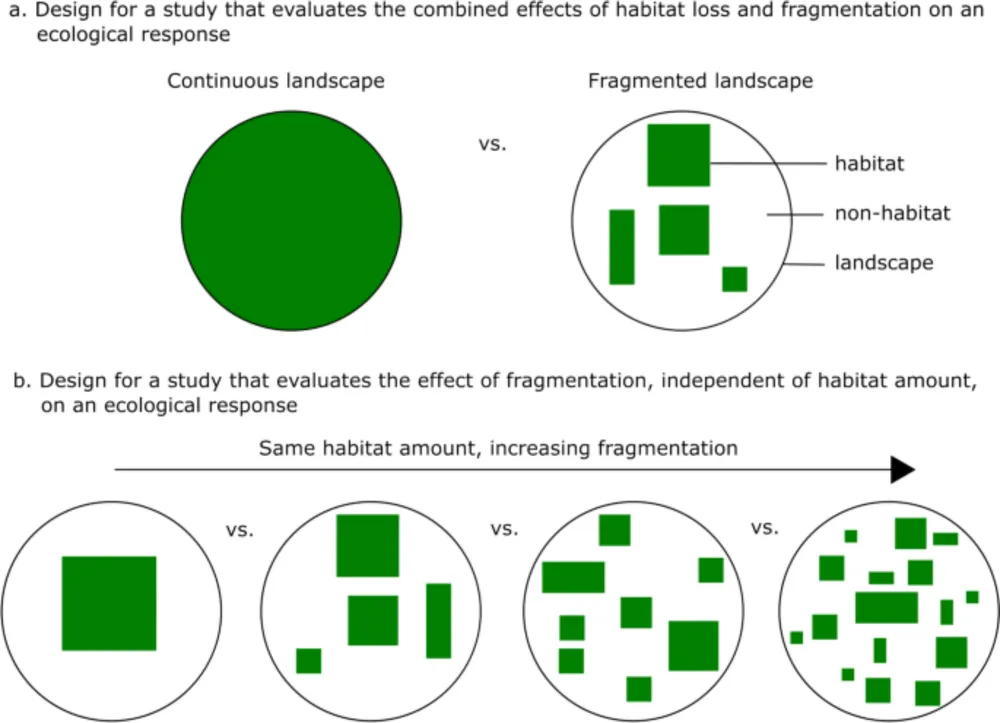

##### 📄 Species age shapes niche position and specialization in Neotropical vertebrates ✨ AI title

Shared by **Carlos Calderón del Cid** [@caldecid.bsky.social](https://bsky.app/profile/caldecid.bsky.social) · 2026-05-25 · 💚 14 likes on Bluesky

```
<div class='tag-row'><span class='tag tag-macroecology'>macroecology</span><span class='tag tag-traits'>traits</span></div>
{% raw %}How does species age influence niche position and specialization across the Neotropics? In a new study published in @ecography.bsky.social with @bruvilela.bsky.social, @fabrovillalobos.bsky.social , and R Dobrovolski:{% endraw %}
```

**link:** https://doi.org/10.1002/ecog.08192  
[View Original Post on Bluesky](https://bsky.app/profile/did:plc:unmx7nfnjbowe7zxqwsdmpu2/post/3mmosf37lqk2y)↑ Up

[output not shown]

[figure not shown]

##### 📄 Mass flowering of the seagrass Posidonia oceanica after 2022 record-breaking marine heatwaves, a Pan-Mediterranean study

Shared by **Jérémy Carlot** [@jerem-carlot.bsky.social](https://bsky.app/profile/jerem-carlot.bsky.social) · 2026-05-25 · 💚 19 likes on Bluesky

```
<div class='tag-row'><span class='tag tag-coastal'>coastal</span><span class='tag tag-climate'>climate</span><span class='tag tag-macroecology'>macroecology</span></div>
{% raw %}Our study is now out in @commsearth.nature.com. 2022 heatwaves triggered a record mass flowering of Mediterranean Posidonia oceanica. 🌊 A sign of resilience or a red flag for ocean health? The answer here: Study led by Patrick Austruch 🌱 🌐{% endraw %}
```

**link:** https://doi.org/10.1038/s43247-026-03631-8  
[View Original Post on Bluesky](https://bsky.app/profile/did:plc:geytktsrkn74y3b6lpwszt66/post/3mmogrfiwjc2d)↑ Up

[output not shown]

[figure not shown]

##### 📄 The fate of mountain biodiversity in a warming world

Shared by **Nature Reviews Biodiversity** [@natrevbiodiv.nature.com](https://bsky.app/profile/natrevbiodiv.nature.com) · 2026-05-25 · 💚 10 likes on Bluesky

```
<div class='tag-row'><span class='tag tag-climate'>climate</span><span class='tag tag-macroecology'>macroecology</span></div>
{% raw %}New online! The fate of mountain biodiversity in a warming world{% endraw %}
```

**link:** http://dlvr.it/TSj6dQ  
[View Original Post on Bluesky](https://bsky.app/profile/did:plc:y3v4l27oii2ecfrit6h6s6oy/post/3mmno7naypv2t)↑ Up

[output not shown]

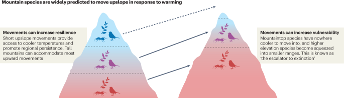

##### 📄 Hierarchical Spatial Data Subdivision into Topologically Contiguous Units [R package hespdiv version 1.2.10]

Shared by **Andrej Spiridonov** [@andrejpaleo.bsky.social](https://bsky.app/profile/andrejpaleo.bsky.social) · 2026-05-24 · 💚 17 likes on Bluesky

```
<div class='tag-row'><span class='tag tag-methods'>methods</span><span class='tag tag-macroecology'>macroecology</span><span class='tag tag-data'>data</span></div>
{% raw %}The R package 'hespdiv' is now in the CRAN! 🥳 Now automatic hierarchical and statistically testable contiguous bioregionalization is available for everyone! Bretskyan_hiearchy 🧪⚒️ EvoBio Paleobio Geology Biogeography Macroecology{% endraw %}
```

**link:** https://cran.rstudio.com/web/packages/hespdiv/index.html  
[View Original Post on Bluesky](https://bsky.app/profile/did:plc:qb6x3o2dt7vkteqeqrqpjtxc/post/3mmmq6rpp4c2p)↑ Up

[output not shown]

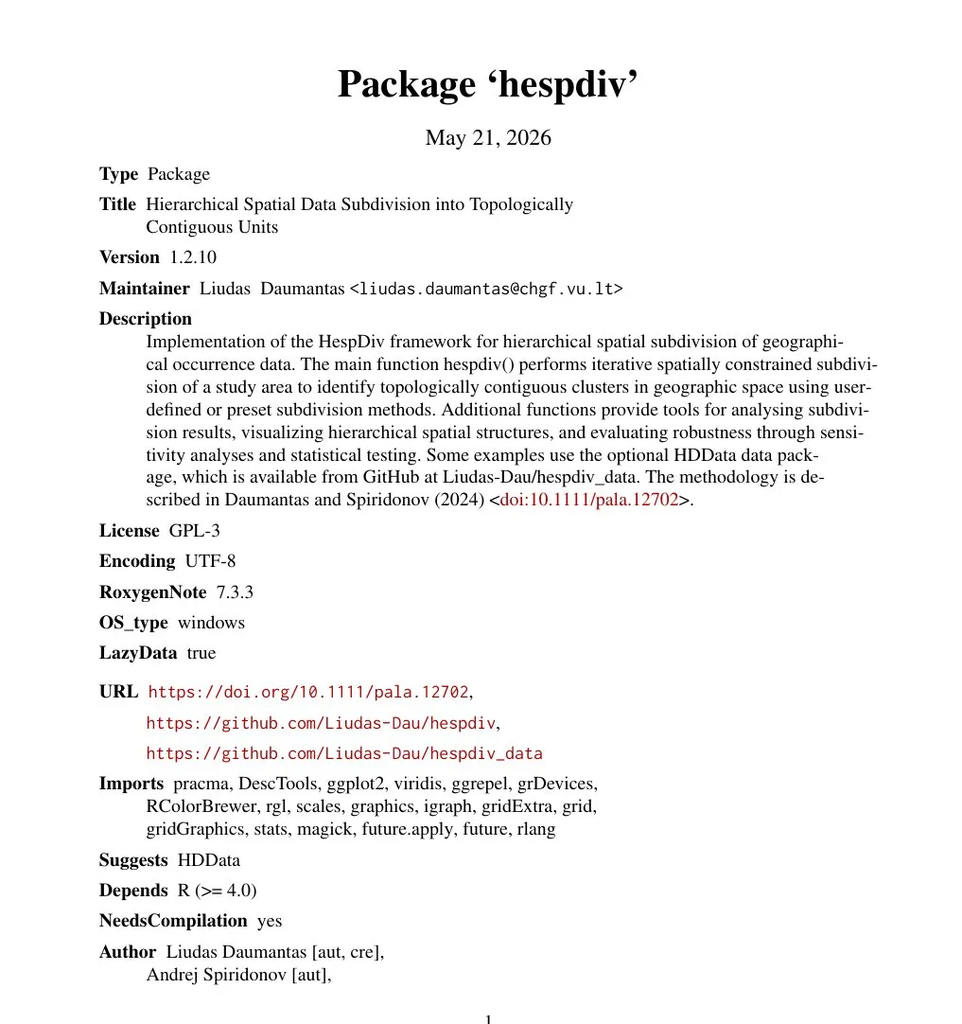